# Интернет-магазин «В один клик» продаёт разные товары. Отчёт магазина за прошлый период показал, что активность покупателей начала снижаться. Привлекать новых клиентов уже не так эффективно. Возможный выход — удерживать активность постоянных клиентов. Сделать это можно с помощью персонализированных предложений.«В один клик» — современная компания, поэтому её руководство не хочет принимать решения просто так — только на основе анализа данных и бизнес-моделирования. Итак, нашей задачей будет разработать решение, которое позволит персонализировать предложения постоянным клиентам, чтобы увеличить их покупательскую активность. В первую очередь, предстоит изучить данные, исследовать и обработать их так, чтобы получить максимальный результат. Далее предстоит построение непосредственно моделей МО, с этим нам в будущем помогут пайплайны, которые слегка автоматизируют большую часть процессов и помогут эффективно вычислить самую точную модель МО. Дальнейшим шагом будет применение лучшей модели для сегментации клиентов по процентному отношению клиента к той или иной категории и дальнейшее изучения нужной нам группы с целью выдвижения некоторых гипотез об улучшении качества сервиса и решения главной проблемы: остановить снижение финансовой активности клиента.

## 1. Шаг. Загрузка данных

### 1.1 Загрузка библиотек и данных

```python
!pip install phik
```

```python
!pip install shap
```

```python
import pandas as pd
import matplotlib.pyplot as plt
import seaborn as sns
import phik
import shap
from sklearn.model_selection import train_test_split
from sklearn.pipeline import Pipeline
from sklearn.preprocessing import OneHotEncoder, OrdinalEncoder, StandardScaler, MinMaxScaler, RobustScaler
from sklearn.compose import ColumnTransformer
from sklearn.impute import SimpleImputer
from sklearn.metrics import roc_auc_score
from sklearn.model_selection import RandomizedSearchCV
from sklearn.linear_model import LogisticRegression
from sklearn.neighbors import KNeighborsClassifier
from sklearn.tree import DecisionTreeClassifier
from sklearn.svm import SVC
```

```python
market_file = pd.read_csv('market_file.csv')
market_money = pd.read_csv('market_money.csv')
market_time = pd.read_csv('market_time.csv')
money = pd.read_csv('money.csv', sep=';', decimal=',')
pd.set_option('display.max_columns', None)
```

Все импортировали и подгрузили, исправили нюансы в датафрейме money

### 1.2 Проверим корректность данных

```python
market_file.info()
```

```
<class 'pandas.core.frame.DataFrame'>
RangeIndex: 1300 entries, 0 to 1299
Data columns (total 13 columns):
 #   Column                               Non-Null Count  Dtype
---  ------                               --------------  -----
 0   id                                   1300 non-null   int64
 1   Покупательская активность            1300 non-null   object
 2   Тип сервиса                          1300 non-null   object
 3   Разрешить сообщать                   1300 non-null   object
 4   Маркет_актив_6_мес                   1300 non-null   float64
 5   Маркет_актив_тек_мес                 1300 non-null   int64
 6   Длительность                         1300 non-null   int64
 7   Акционные_покупки                    1300 non-null   float64
 8   Популярная_категория                 1300 non-null   object
 9   Средний_просмотр_категорий_за_визит  1300 non-null   int64
 10  Неоплаченные_продукты_штук_квартал   1300 non-null   int64
 11  Ошибка_сервиса                       1300 non-null   int64
 12  Страниц_за_визит                     1300 non-null   int64
dtypes: float64(2), int64(7), object(4)
memory usage: 132.2+ KB
```

```python
market_money.info()
```

```
<class 'pandas.core.frame.DataFrame'>
RangeIndex: 3900 entries, 0 to 3899
Data columns (total 3 columns):
 #   Column   Non-Null Count  Dtype
---  ------   --------------  -----
 0   id       3900 non-null   int64
 1   Период   3900 non-null   object
 2   Выручка  3900 non-null   float64
dtypes: float64(1), int64(1), object(1)
memory usage: 91.5+ KB
```

```python
market_time.info()
```

```
<class 'pandas.core.frame.DataFrame'>
RangeIndex: 2600 entries, 0 to 2599
Data columns (total 3 columns):
 #   Column  Non-Null Count  Dtype
---  ------  --------------  -----
 0   id      2600 non-null   int64
 1   Период  2600 non-null   object
 2   минут   2600 non-null   int64
dtypes: int64(2), object(1)
memory usage: 61.1+ KB
```

```python
money.info()
```

```
<class 'pandas.core.frame.DataFrame'>
RangeIndex: 1300 entries, 0 to 1299
Data columns (total 2 columns):
 #   Column   Non-Null Count  Dtype
---  ------   --------------  -----
 0   id       1300 non-null   int64
 1   Прибыль  1300 non-null   float64
dtypes: float64(1), int64(1)
memory usage: 20.4 KB
```

Тут все верно и хорошо

## 2 Шаг. Предобработка данных

### market_file

```python
market_file.head(1)
```

|  | id | Покупательская активность | Тип сервиса | Разрешить сообщать | Маркет_актив_6_мес | Маркет_актив_тек_мес | Длительность | Акционные_покупки | Популярная_категория | Средний_просмотр_категорий_за_визит | Неоплаченные_продукты_штук_квартал | Ошибка_сервиса | Страниц_за_визит |
| --- | --- | --- | --- | --- | --- | --- | --- | --- | --- | --- | --- | --- | --- |
| 0 | 215348 | Снизилась | премиум | да | 3.4 | 5 | 121 | 0.0 | Товары для детей | 6 | 2 | 1 | 5 |

Для начала переименуем столбцы к адекватным регистрам

```python
market_file = market_file.rename(columns={'Покупательская активность':'покупательская_активность',
                                          'Тип сервиса':'тип_сервиса',
                                          'Разрешить сообщать':'разрешить_сообщать',
                                          'Маркет_актив_6_мес':'маркет_актив_6_мес',
                                          'Маркет_актив_тек_мес':'маркет_актив_тек_мес',
                                          'Длительность':'длительность',
                                          'Акционные_покупки':'акционные_покупки',
                                          'Популярная_категория':'популярная_категория',
                                          'Средний_просмотр_категорий_за_визит':'средний_просмотр_категорий_за_визит',
                                          'Неоплаченные_продукты_штук_квартал':'неоплаченные_продукты_штук_квартал',
                                          'Ошибка_сервиса':'ошибка_сервиса',
                                          'Страниц_за_визит':'страниц_за_визит'
                          })
```

```python
market_file.head(1)
```

|  | id | покупательская_активность | тип_сервиса | разрешить_сообщать | маркет_актив_6_мес | маркет_актив_тек_мес | длительность | акционные_покупки | популярная_категория | средний_просмотр_категорий_за_визит | неоплаченные_продукты_штук_квартал | ошибка_сервиса | страниц_за_визит |
| --- | --- | --- | --- | --- | --- | --- | --- | --- | --- | --- | --- | --- | --- |
| 0 | 215348 | Снизилась | премиум | да | 3.4 | 5 | 121 | 0.0 | Товары для детей | 6 | 2 | 1 | 5 |

Теперь изменим типы данных в столбцах

```python
market_file.dtypes
```

```
id                                       int64
покупательская_активность               object
тип_сервиса                             object
разрешить_сообщать                      object
маркет_актив_6_мес                     float64
маркет_актив_тек_мес                     int64
длительность                             int64
акционные_покупки                      float64
популярная_категория                    object
средний_просмотр_категорий_за_визит      int64
неоплаченные_продукты_штук_квартал       int64
ошибка_сервиса                           int64
страниц_за_визит                         int64
dtype: object
```

Тут все хорошо

Однако теперь надо поменять значения внутри столбцов потому, что они кривые. Например в типе сервиса есть стандарт и стандартТ.

```python
for column in market_file.columns[1:4]:
    print(market_file[column].unique())
```

```
['Снизилась' 'Прежний уровень']
['премиум' 'стандартт' 'стандарт']
['да' 'нет']
```

```python
market_file['тип_сервиса'] = market_file['тип_сервиса'].replace(['стандартт'],'стандарт')
```

```python
market_file['тип_сервиса'].unique()
```

```
array(['премиум', 'стандарт'], dtype=object)
```

### market_money

```python
market_money.info()
```

```
<class 'pandas.core.frame.DataFrame'>
RangeIndex: 3900 entries, 0 to 3899
Data columns (total 3 columns):
 #   Column   Non-Null Count  Dtype
---  ------   --------------  -----
 0   id       3900 non-null   int64
 1   Период   3900 non-null   object
 2   Выручка  3900 non-null   float64
dtypes: float64(1), int64(1), object(1)
memory usage: 91.5+ KB
```

```python
market_money = market_money.rename(columns={
    'Период':'период',
    'Выручка':'выручка'
})
```

```python
market_money.dtypes
```

```
id           int64
период      object
выручка    float64
dtype: object
```

```python
market_money.head(3)
```

|  | id | период | выручка |
| --- | --- | --- | --- |
| 0 | 215348 | препредыдущий_месяц | 0.0 |
| 1 | 215348 | текущий_месяц | 3293.1 |
| 2 | 215348 | предыдущий_месяц | 0.0 |

С типами данных все хорошо, теперь изменим значения внутри столбцов

```python
market_money['период'].unique()
```

```
array(['препредыдущий_месяц', 'текущий_месяц', 'предыдущий_месяц'],
      dtype=object)
```

```python
market_money['период'].value_counts()
```

```
препредыдущий_месяц    1300
текущий_месяц          1300
предыдущий_месяц       1300
Name: период, dtype: int64
```

### market_time

```python
market_time.head(2)
```

|  | id | Период | минут |
| --- | --- | --- | --- |
| 0 | 215348 | текущий_месяц | 14 |
| 1 | 215348 | предыдцщий_месяц | 13 |

```python
market_time = market_time.rename(columns={
    'Период':'период',
})
```

```python
market_time.dtypes
```

```
id         int64
период    object
минут      int64
dtype: object
```

Типы поменяли, теперь опять пофиксим значения внутри столбца период

```python
market_time['период'].unique()
```

```
array(['текущий_месяц', 'предыдцщий_месяц'], dtype=object)
```

```python
market_time['период'] = market_time['период'].replace(['предыдцщий_месяц'],'предыдущий_месяц')
```

### money

```python
money.head(5)
```

|  | id | Прибыль |
| --- | --- | --- |
| 0 | 215348 | 0.98 |
| 1 | 215349 | 4.16 |
| 2 | 215350 | 3.13 |
| 3 | 215351 | 4.87 |
| 4 | 215352 | 4.21 |

```python
money.info()
```

```
<class 'pandas.core.frame.DataFrame'>
RangeIndex: 1300 entries, 0 to 1299
Data columns (total 2 columns):
 #   Column   Non-Null Count  Dtype
---  ------   --------------  -----
 0   id       1300 non-null   int64
 1   Прибыль  1300 non-null   float64
dtypes: float64(1), int64(1)
memory usage: 20.4 KB
```

Тут все круто и замечательно

Дубликаты пока что не будем трогать, но изучим

```python
market_file.duplicated().sum()
```

```
0
```

```python
market_money.duplicated().sum()
```

```
0
```

```python
market_time.duplicated().sum()
```

```
0
```

```python
money.duplicated().sum()
```

```
0
```

## 3 Шаг. Исследовательский анализ данных

### 3.1 Изучим статистику

#### market_file

```python
market_file.head(1)
```

|  | id | покупательская_активность | тип_сервиса | разрешить_сообщать | маркет_актив_6_мес | маркет_актив_тек_мес | длительность | акционные_покупки | популярная_категория | средний_просмотр_категорий_за_визит | неоплаченные_продукты_штук_квартал | ошибка_сервиса | страниц_за_визит |
| --- | --- | --- | --- | --- | --- | --- | --- | --- | --- | --- | --- | --- | --- |
| 0 | 215348 | Снизилась | премиум | да | 3.4 | 5 | 121 | 0.0 | Товары для детей | 6 | 2 | 1 | 5 |

Выведем статистику всех числовых столбцов кроме id

```python
market_file.describe().iloc[:, 1:]
```

|  | маркет_актив_6_мес | маркет_актив_тек_мес | длительность | акционные_покупки | средний_просмотр_категорий_за_визит | неоплаченные_продукты_штук_квартал | ошибка_сервиса | страниц_за_визит |
| --- | --- | --- | --- | --- | --- | --- | --- | --- |
| count | 1300.000000 | 1300.000000 | 1300.000000 | 1300.000000 | 1300.00000 | 1300.000000 | 1300.000000 | 1300.000000 |
| mean | 4.253769 | 4.011538 | 601.898462 | 0.319808 | 3.27000 | 2.840000 | 4.185385 | 8.176923 |
| std | 1.014814 | 0.696868 | 249.856289 | 0.249843 | 1.35535 | 1.971451 | 1.955298 | 3.978126 |
| min | 0.900000 | 3.000000 | 110.000000 | 0.000000 | 1.00000 | 0.000000 | 0.000000 | 1.000000 |
| 25% | 3.700000 | 4.000000 | 405.500000 | 0.170000 | 2.00000 | 1.000000 | 3.000000 | 5.000000 |
| 50% | 4.200000 | 4.000000 | 606.000000 | 0.240000 | 3.00000 | 3.000000 | 4.000000 | 8.000000 |
| 75% | 4.900000 | 4.000000 | 806.000000 | 0.300000 | 4.00000 | 4.000000 | 6.000000 | 11.000000 |
| max | 6.600000 | 5.000000 | 1079.000000 | 0.990000 | 6.00000 | 10.000000 | 9.000000 | 20.000000 |

Теперь для каждого столбца выведем подсчет уникальных значений

```python
columns = ['покупательская_активность', 'тип_сервиса', 'разрешить_сообщать', 'популярная_категория']

for col in columns:
    print(f"Столбец: {col}")
    print(market_file[col].value_counts())
    print("\n")
```

```
Столбец: покупательская_активность
Прежний уровень    802
Снизилась          498
Name: покупательская_активность, dtype: int64


Столбец: тип_сервиса
стандарт    924
премиум     376
Name: тип_сервиса, dtype: int64


Столбец: разрешить_сообщать
да     962
нет    338
Name: разрешить_сообщать, dtype: int64


Столбец: популярная_категория
Товары для детей                        330
Домашний текстиль                       251
Косметика и аксесуары                   223
Техника для красоты и здоровья          184
Мелкая бытовая техника и электроника    174
Кухонная посуда                         138
Name: популярная_категория, dtype: int64
```

Изучим пропуски для каждого датафрейма

```python
def analyze_missing_values(df: pd.DataFrame) -> pd.DataFrame:
    missing_values = df.isnull().sum()
    missing_analysis = pd.DataFrame({'Кол-во пропущенных значений / столбец': missing_values})
    return missing_analysis.sort_values(by='Кол-во пропущенных значений / столбец', ascending=False)

frames = [market_file, market_money, market_time, money]
for frame in frames:
    print(analyze_missing_values(frame))
```

```
                                     Кол-во пропущенных значений / столбец
id                                                                       0
покупательская_активность                                                0
тип_сервиса                                                              0
разрешить_сообщать                                                       0
маркет_актив_6_мес                                                       0
маркет_актив_тек_мес                                                     0
длительность                                                             0
акционные_покупки                                                        0
популярная_категория                                                     0
средний_просмотр_категорий_за_визит                                      0
неоплаченные_продукты_штук_квартал                                       0
ошибка_сервиса                                                           0
страниц_за_визит                                                         0
         Кол-во пропущенных значений / столбец
id                                           0
период                                       0
выручка                                      0
        Кол-во пропущенных значений / столбец
id                                          0
период                                      0
минут                                       0
         Кол-во пропущенных значений / столбец
id                                           0
Прибыль                                      0
```

А это значит, что данные качественные, нам повезло!

#### market_money

```python
market_money.describe().iloc[:, 1:]
```

|  | выручка |
| --- | --- |
| count | 3900.000000 |
| mean | 5025.696051 |
| std | 1777.704104 |
| min | 0.000000 |
| 25% | 4590.150000 |
| 50% | 4957.500000 |
| 75% | 5363.000000 |
| max | 106862.200000 |

```python
market_money['период'].value_counts()
```

```
препредыдущий_месяц    1300
текущий_месяц          1300
предыдущий_месяц       1300
Name: период, dtype: int64
```

#### market_time

```python
market_time.describe().iloc[:, 1:]
```

|  | минут |
| --- | --- |
| count | 2600.000000 |
| mean | 13.336154 |
| std | 4.080198 |
| min | 4.000000 |
| 25% | 10.000000 |
| 50% | 13.000000 |
| 75% | 16.000000 |
| max | 23.000000 |

```python
market_time['период'].value_counts()
```

```
текущий_месяц       1300
предыдущий_месяц    1300
Name: период, dtype: int64
```

```python
money.describe().iloc[:, 1:]
```

|  | Прибыль |
| --- | --- |
| count | 1300.000000 |
| mean | 3.996631 |
| std | 1.013722 |
| min | 0.860000 |
| 25% | 3.300000 |
| 50% | 4.045000 |
| 75% | 4.670000 |
| max | 7.430000 |

### 3.2 Теперь построим графики

Возьмем функцию из прошлого проекта, которая построит разные графики в зависимости от категории признака

```python
def plot_column(dataframe, column_name):
    # Проверяем, есть ли в датафрейме столбец 'покупательская_активность' и нужно ли делать разбиение
    if 'покупательская_активность' in dataframe.columns and pd.api.types.is_numeric_dtype(dataframe[column_name]):
        plt.figure(figsize=(12, 5))
        plt.subplot(1, 2, 1)
        sns.histplot(data=dataframe, x=column_name, hue="покупательская_активность", kde=True)
        plt.title(f"Гистограмма столбца: {column_name}")
        plt.subplot(1, 2, 2)
        sns.boxplot(x="покупательская_активность", y=column_name, data=dataframe)
        plt.title(f"Ящик с усами столбца: {column_name}")
        plt.tight_layout()
        plt.show()
    elif pd.api.types.is_numeric_dtype(dataframe[column_name]):
        plt.figure(figsize=(12, 5))
        plt.subplot(1, 2, 1)
        sns.histplot(dataframe[column_name], kde=True)
        plt.title(f"Гистограмма столбца: {column_name}")
        plt.subplot(1, 2, 2)
        sns.boxplot(x=dataframe[column_name])
        plt.title(f"Ящик с усами столбца: {column_name}")
        plt.tight_layout()
        plt.show()
    else:
        plt.figure(figsize=(8, 8))
        dataframe[column_name].value_counts().plot.pie(autopct='%1.1f%%', startangle=90)
        plt.title(f"Pie chart столбца: {column_name}")
        plt.ylabel('')
        plt.show()

def plot_all_columns(dataframe):
    for column_name in dataframe.columns:
        print(f"Plotting for column: {column_name}")
        plot_column(dataframe, column_name)
        print("-" * 50)
```

#### market_file

```
Plotting for column: покупательская_активность
```

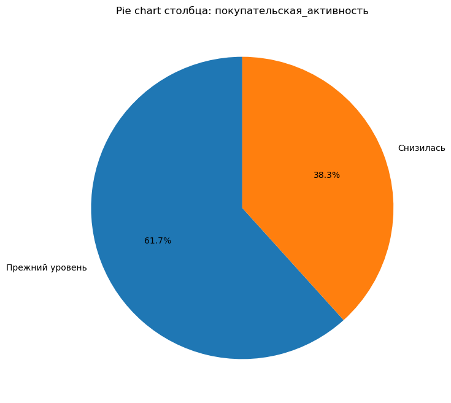

```
--------------------------------------------------
Plotting for column: тип_сервиса
```

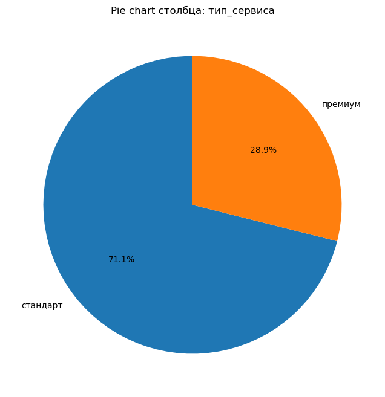

```
--------------------------------------------------
Plotting for column: разрешить_сообщать
```

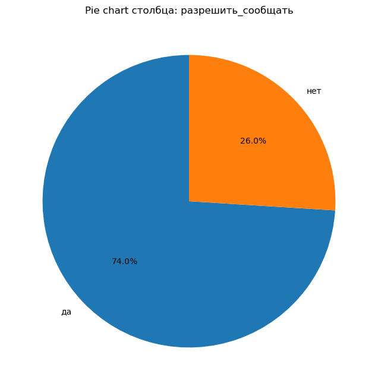

```
--------------------------------------------------
Plotting for column: маркет_актив_6_мес
```

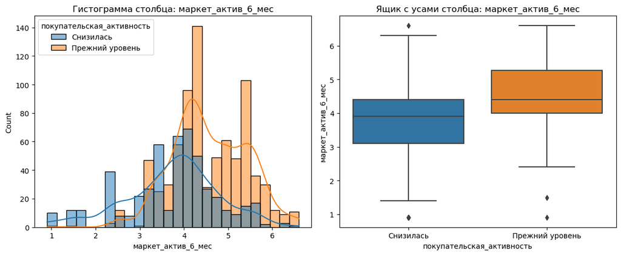

```
--------------------------------------------------
Plotting for column: маркет_актив_тек_мес
```

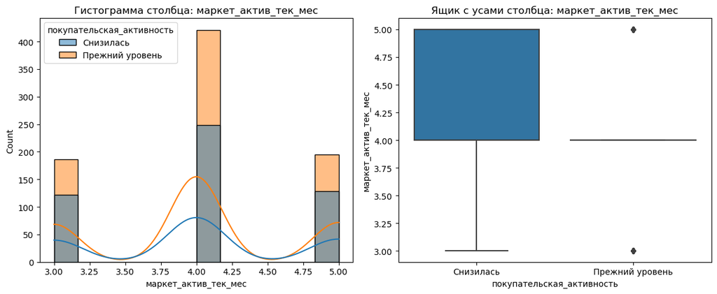

```
--------------------------------------------------
Plotting for column: длительность
```

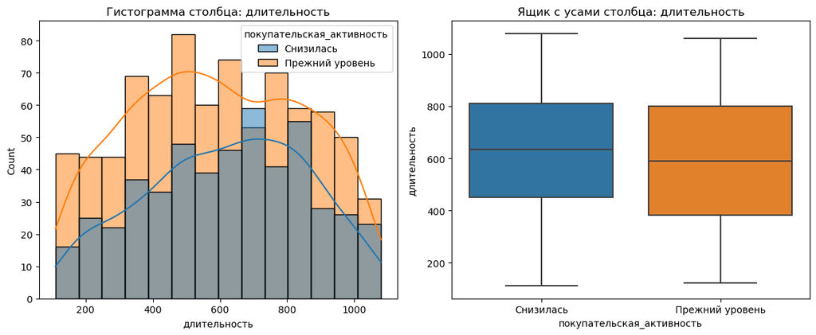

```
--------------------------------------------------
Plotting for column: акционные_покупки
```

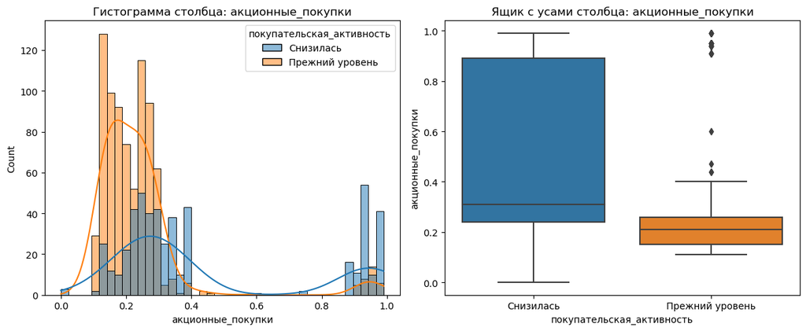

```
--------------------------------------------------
Plotting for column: популярная_категория
```

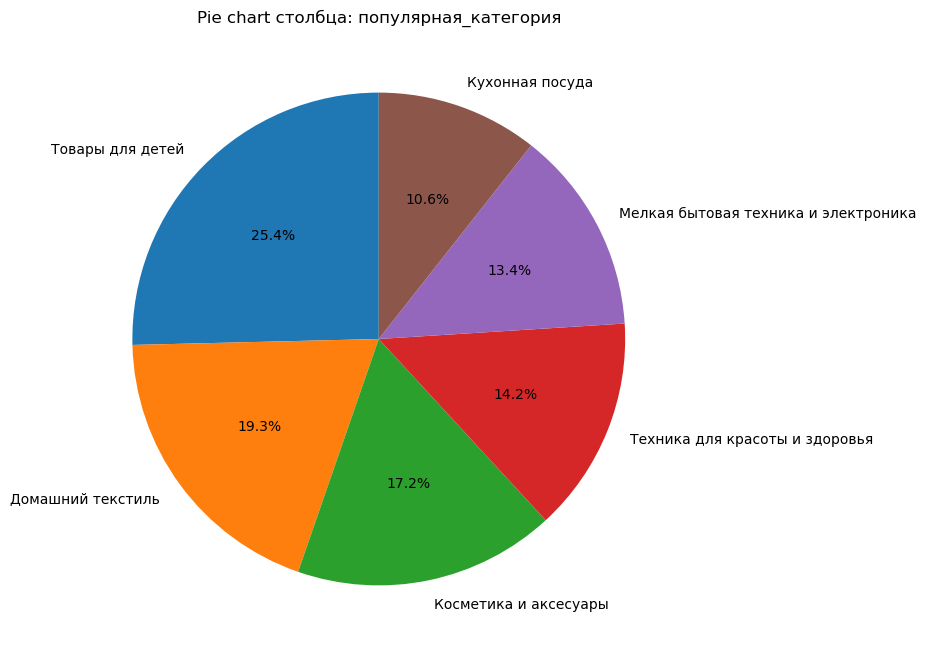

```
--------------------------------------------------
Plotting for column: средний_просмотр_категорий_за_визит
```

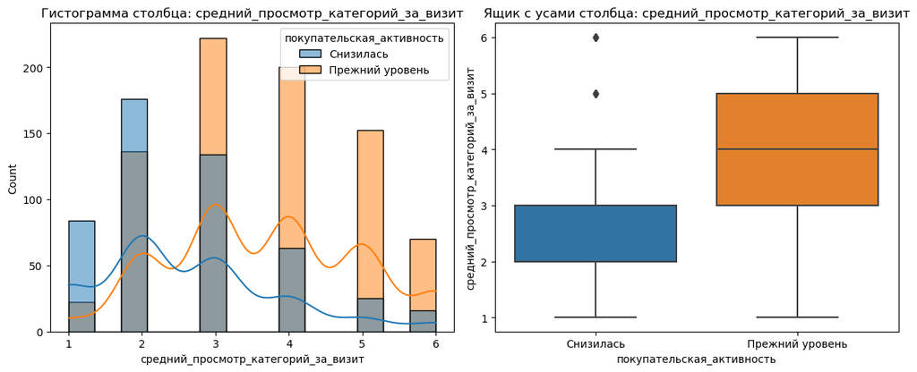

```
--------------------------------------------------
Plotting for column: неоплаченные_продукты_штук_квартал
```

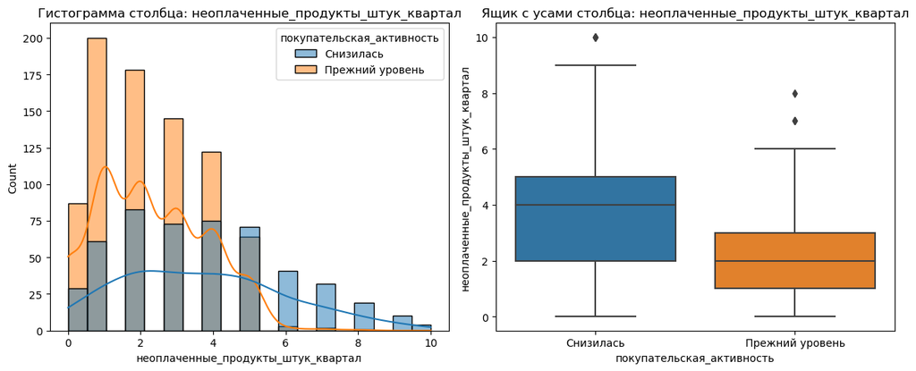

```
--------------------------------------------------
Plotting for column: ошибка_сервиса
```

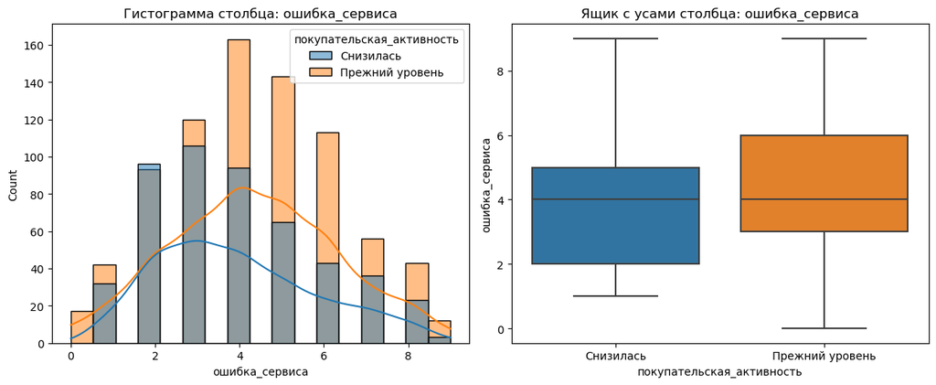

```
--------------------------------------------------
Plotting for column: страниц_за_визит
```

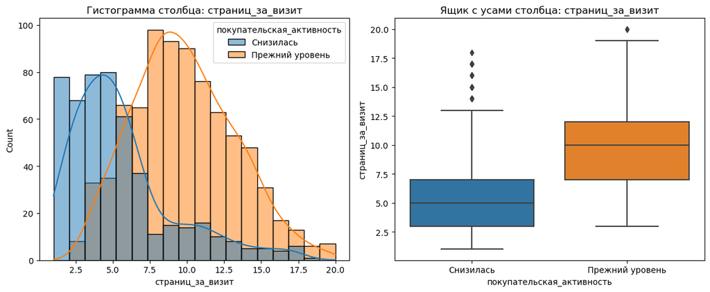

```python
plot_all_columns(market_file.iloc[:, 1:])
```

По категориальным все понятно. Рассмотрим что получилось в числовых. В столбце маркет_актив_6_мес четыре выброса но в целом распределение нормальное для категории 'снизилась', а для категории 'прежний уровень' оно в целом находится в том же промежутке, однако немного бимодальное. актив_тек_мес пропускаем. В столбце длительность для обеих категорий распределение почти одинаковое, однако прежний уровень левее. В столбце акционные_покупки достаточно выбросов для категории прежний уровень и распределение скорее бимодальное. В средний_просмотр_категорий_за_визит распределение убывает слева направо, а в другой категории примерно стабильное. В неоплаченных продуктах есть три выброса, прежний уровень убывает, а снизилась +- стабилен. Ошибка сервиса имеет нормальное распределение для прежнего уровня и смещенное влево для снизилась. страниц_за_визит прежний уровень имеет нормальное распределение, снизилась тоже, но сильно смещенное влево.

#### market_money

```
Plotting for column: период
```

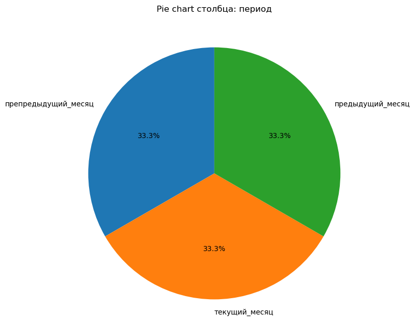

```
--------------------------------------------------
Plotting for column: выручка
```

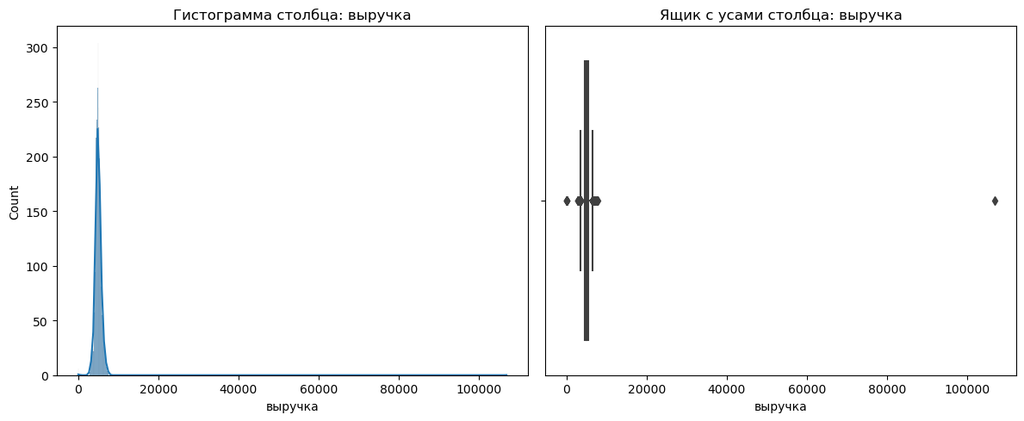

```python
plot_all_columns(market_money.iloc[:, 1:])
```

Тут явно надо будет удалить один жесткий выброс и нулевые значения

Отберем только те ID у которых хотя бы на одном из периодов было значение 0 и соотвественно человека у которого жесткий выброс

```python
market_money['id'].nunique()
```

```
1300
```

```python
filtered_ids = market_money.groupby('id')['выручка'].apply(lambda x: ((x > 100000) | (x == 0)).any()).reset_index()
filtered_ids = filtered_ids[filtered_ids['выручка'] == False]
market_money = market_money[market_money['id'].isin(filtered_ids['id'])]
```

```python
market_money['id'].nunique()
```

```
1296
```

Таким образом мы убрали 4 человека

```
Plotting for column: период
```

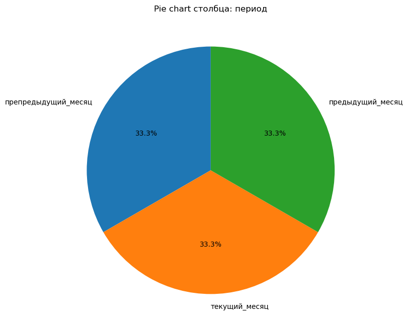

```
--------------------------------------------------
Plotting for column: выручка
```

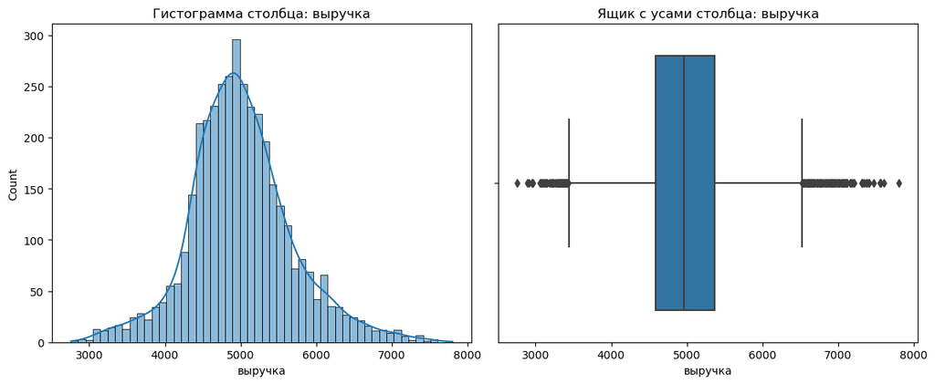

```python
plot_all_columns(market_money.iloc[:, 1:])
```

Стало лучше!

#### market_time

```
Plotting for column: период
```

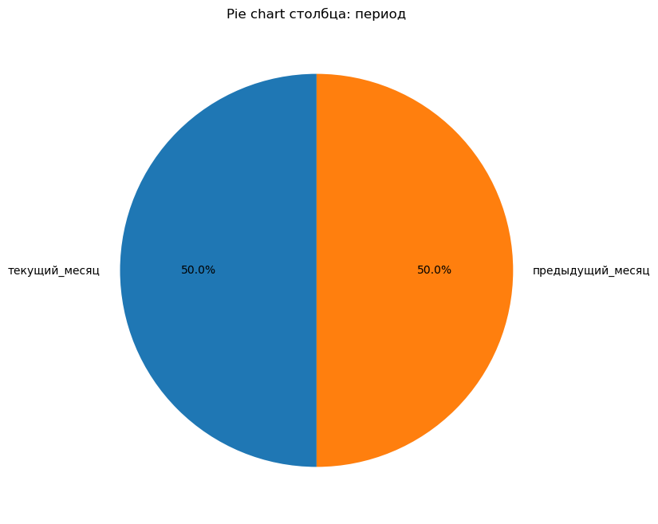

```
--------------------------------------------------
Plotting for column: минут
```

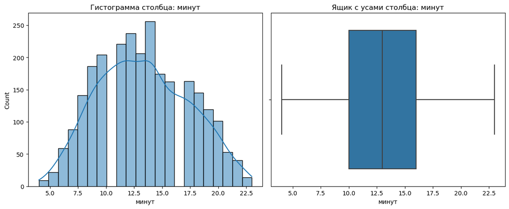

```python
plot_all_columns(market_time.iloc[:, 1:])
```

Тут все хорошо

#### money

```
Plotting for column: Прибыль
```

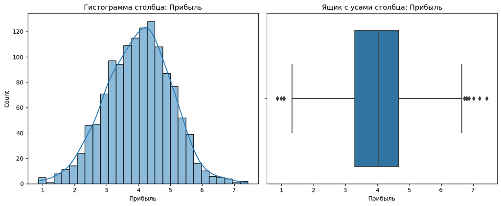

```python
plot_all_columns(money.iloc[:, 1:])
```

Тут тоже все неплохо

### 3.3 Отберем нужных нам пользователей

```python
market_file['id'].nunique()
```

```
1300
```

```python
market_time['id'].nunique()
```

```
1300
```

```python
unique_ids = market_money['id'].unique()

market_file = market_file[market_file['id'].isin(unique_ids)]

market_time = market_time[market_time['id'].isin(unique_ids)]
```

```python
market_file['id'].nunique()
```

```
1296
```

```python
market_time['id'].nunique()
```

```
1296
```

Собственно тут тоже пропало по 4 человека

## 4 Шаг. Объединение таблиц

### 4.1 Объединим таблицы market_file, market_money, market_time

```python
market_file.head(1)
```

|  | id | покупательская_активность | тип_сервиса | разрешить_сообщать | маркет_актив_6_мес | маркет_актив_тек_мес | длительность | акционные_покупки | популярная_категория | средний_просмотр_категорий_за_визит | неоплаченные_продукты_штук_квартал | ошибка_сервиса | страниц_за_визит |
| --- | --- | --- | --- | --- | --- | --- | --- | --- | --- | --- | --- | --- | --- |
| 1 | 215349 | Снизилась | премиум | да | 4.4 | 4 | 819 | 0.75 | Товары для детей | 4 | 4 | 2 | 5 |

```python
market_money.head(1)
```

|  | id | период | выручка |
| --- | --- | --- | --- |
| 3 | 215349 | препредыдущий_месяц | 4472.0 |

```python
market_time.head(1)
```

|  | id | период | минут |
| --- | --- | --- | --- |
| 2 | 215349 | текущий_месяц | 10 |

```python
market_file.info()
```

```
<class 'pandas.core.frame.DataFrame'>
Int64Index: 1296 entries, 1 to 1299
Data columns (total 13 columns):
 #   Column                               Non-Null Count  Dtype
---  ------                               --------------  -----
 0   id                                   1296 non-null   int64
 1   покупательская_активность            1296 non-null   object
 2   тип_сервиса                          1296 non-null   object
 3   разрешить_сообщать                   1296 non-null   object
 4   маркет_актив_6_мес                   1296 non-null   float64
 5   маркет_актив_тек_мес                 1296 non-null   int64
 6   длительность                         1296 non-null   int64
 7   акционные_покупки                    1296 non-null   float64
 8   популярная_категория                 1296 non-null   object
 9   средний_просмотр_категорий_за_визит  1296 non-null   int64
 10  неоплаченные_продукты_штук_квартал   1296 non-null   int64
 11  ошибка_сервиса                       1296 non-null   int64
 12  страниц_за_визит                     1296 non-null   int64
dtypes: float64(2), int64(7), object(4)
memory usage: 141.8+ KB
```

```python
market_money.info()
```

```
<class 'pandas.core.frame.DataFrame'>
Int64Index: 3888 entries, 3 to 3899
Data columns (total 3 columns):
 #   Column   Non-Null Count  Dtype
---  ------   --------------  -----
 0   id       3888 non-null   int64
 1   период   3888 non-null   object
 2   выручка  3888 non-null   float64
dtypes: float64(1), int64(1), object(1)
memory usage: 121.5+ KB
```

```python
market_time.info()
```

```
<class 'pandas.core.frame.DataFrame'>
Int64Index: 2592 entries, 2 to 2599
Data columns (total 3 columns):
 #   Column  Non-Null Count  Dtype
---  ------  --------------  -----
 0   id      2592 non-null   int64
 1   период  2592 non-null   object
 2   минут   2592 non-null   int64
dtypes: int64(2), object(1)
memory usage: 81.0+ KB
```

Теперь пора смержить три таблицы учитывая что у нас есть различия в периодах, да и самих периода 3

```python
money_1 = market_money[market_money['период']== 'препредыдущий_месяц']
money_1.columns = ['id', 'period1', 'earning1']
market_file = market_file.merge(money_1)
market_file.head(1)
```

|  | id | покупательская_активность | тип_сервиса | разрешить_сообщать | маркет_актив_6_мес | маркет_актив_тек_мес | длительность | акционные_покупки | популярная_категория | средний_просмотр_категорий_за_визит | неоплаченные_продукты_штук_квартал | ошибка_сервиса | страниц_за_визит | period1 | earning1 |
| --- | --- | --- | --- | --- | --- | --- | --- | --- | --- | --- | --- | --- | --- | --- | --- |
| 0 | 215349 | Снизилась | премиум | да | 4.4 | 4 | 819 | 0.75 | Товары для детей | 4 | 4 | 2 | 5 | препредыдущий_месяц | 4472.0 |

```python
money_2 = market_money[market_money['период']== 'предыдущий_месяц']
money_2.columns = ['id', 'period2', 'earning2']
market_file = market_file.merge(money_2)
market_file.head(1)
```

|  | id | покупательская_активность | тип_сервиса | разрешить_сообщать | маркет_актив_6_мес | маркет_актив_тек_мес | длительность | акционные_покупки | популярная_категория | средний_просмотр_категорий_за_визит | неоплаченные_продукты_штук_квартал | ошибка_сервиса | страниц_за_визит | period1 | earning1 | period2 | earning2 |
| --- | --- | --- | --- | --- | --- | --- | --- | --- | --- | --- | --- | --- | --- | --- | --- | --- | --- |
| 0 | 215349 | Снизилась | премиум | да | 4.4 | 4 | 819 | 0.75 | Товары для детей | 4 | 4 | 2 | 5 | препредыдущий_месяц | 4472.0 | предыдущий_месяц | 5216.0 |

```python
money_3 = market_money[market_money['период']== 'текущий_месяц']
money_3.columns = ['id', 'period3', 'earning3']
market_file = market_file.merge(money_3)
market_file.head(1)
```

|  | id | покупательская_активность | тип_сервиса | разрешить_сообщать | маркет_актив_6_мес | маркет_актив_тек_мес | длительность | акционные_покупки | популярная_категория | средний_просмотр_категорий_за_визит | неоплаченные_продукты_штук_квартал | ошибка_сервиса | страниц_за_визит | period1 | earning1 | period2 | earning2 | period3 | earning3 |
| --- | --- | --- | --- | --- | --- | --- | --- | --- | --- | --- | --- | --- | --- | --- | --- | --- | --- | --- | --- |
| 0 | 215349 | Снизилась | премиум | да | 4.4 | 4 | 819 | 0.75 | Товары для детей | 4 | 4 | 2 | 5 | препредыдущий_месяц | 4472.0 | предыдущий_месяц | 5216.0 | текущий_месяц | 4971.6 |

```python
time_1 = market_time[market_time['период']== 'предыдущий_месяц']
time_1.columns = ['id', 'period2', 'time2']
market_file = market_file.merge(time_1, on=['id', 'period2'])
market_file.head(1)
```

|  | id | покупательская_активность | тип_сервиса | разрешить_сообщать | маркет_актив_6_мес | маркет_актив_тек_мес | длительность | акционные_покупки | популярная_категория | средний_просмотр_категорий_за_визит | неоплаченные_продукты_штук_квартал | ошибка_сервиса | страниц_за_визит | period1 | earning1 | period2 | earning2 | period3 | earning3 | time2 |
| --- | --- | --- | --- | --- | --- | --- | --- | --- | --- | --- | --- | --- | --- | --- | --- | --- | --- | --- | --- | --- |
| 0 | 215349 | Снизилась | премиум | да | 4.4 | 4 | 819 | 0.75 | Товары для детей | 4 | 4 | 2 | 5 | препредыдущий_месяц | 4472.0 | предыдущий_месяц | 5216.0 | текущий_месяц | 4971.6 | 12 |

```python
time_2 = market_time[market_time['период']== 'текущий_месяц']
time_2.columns = ['id', 'period3', 'time3']
market_file = market_file.merge(time_2, on=['id', 'period3'])
market_file.head(1)
```

|  | id | покупательская_активность | тип_сервиса | разрешить_сообщать | маркет_актив_6_мес | маркет_актив_тек_мес | длительность | акционные_покупки | популярная_категория | средний_просмотр_категорий_за_визит | неоплаченные_продукты_штук_квартал | ошибка_сервиса | страниц_за_визит | period1 | earning1 | period2 | earning2 | period3 | earning3 | time2 | time3 |
| --- | --- | --- | --- | --- | --- | --- | --- | --- | --- | --- | --- | --- | --- | --- | --- | --- | --- | --- | --- | --- | --- |
| 0 | 215349 | Снизилась | премиум | да | 4.4 | 4 | 819 | 0.75 | Товары для детей | 4 | 4 | 2 | 5 | препредыдущий_месяц | 4472.0 | предыдущий_месяц | 5216.0 | текущий_месяц | 4971.6 | 12 | 10 |

```python
market_file.info()
```

```
<class 'pandas.core.frame.DataFrame'>
Int64Index: 1296 entries, 0 to 1295
Data columns (total 21 columns):
 #   Column                               Non-Null Count  Dtype
---  ------                               --------------  -----
 0   id                                   1296 non-null   int64
 1   покупательская_активность            1296 non-null   object
 2   тип_сервиса                          1296 non-null   object
 3   разрешить_сообщать                   1296 non-null   object
 4   маркет_актив_6_мес                   1296 non-null   float64
 5   маркет_актив_тек_мес                 1296 non-null   int64
 6   длительность                         1296 non-null   int64
 7   акционные_покупки                    1296 non-null   float64
 8   популярная_категория                 1296 non-null   object
 9   средний_просмотр_категорий_за_визит  1296 non-null   int64
 10  неоплаченные_продукты_штук_квартал   1296 non-null   int64
 11  ошибка_сервиса                       1296 non-null   int64
 12  страниц_за_визит                     1296 non-null   int64
 13  period1                              1296 non-null   object
 14  earning1                             1296 non-null   float64
 15  period2                              1296 non-null   object
 16  earning2                             1296 non-null   float64
 17  period3                              1296 non-null   object
 18  earning3                             1296 non-null   float64
 19  time2                                1296 non-null   int64
 20  time3                                1296 non-null   int64
dtypes: float64(5), int64(9), object(7)
memory usage: 222.8+ KB
```

Готово!